# Machine Learning Writeup

rokhrzic

2 April 2016

## Basic setup

We begin the task by downloading the dataset and reading it into our environment. We also load the caret package and set a random seed of 3663.

## Exploratory analysis and cleaning data

To make certain the training data is properly formatted and ready to be used for modelling, we undertake a number of exploratory analyses. We look at the structure of our dataset, we calculate the number of missing values and plot the outcome, classe, we are attempting to predict.

```r
str(dat)
```

```
## 'data.frame':    19622 obs. of  160 variables:
##  $ X                       : int  1 2 3 4 5 6 7 8 9 10 ...
##  $ user_name               : Factor w/ 6 levels "adelmo","carlitos",..: 2 2 2 2 2 2 2 2 2 2 ...
##  $ raw_timestamp_part_1    : int  1323084231 1323084231 1323084231 1323084232 1323084232 1323084232 1323084232 1323084232 1323084232 1323084232 ...
##  $ raw_timestamp_part_2    : int  788290 808298 820366 120339 196328 304277 368296 440390 484323 484434 ...
##  $ cvtd_timestamp          : Factor w/ 20 levels "02/12/2011 13:32",..: 9 9 9 9 9 9 9 9 9 9 ...
##  $ new_window              : Factor w/ 2 levels "no","yes": 1 1 1 1 1 1 1 1 1 1 ...
##  $ num_window              : int  11 11 11 12 12 12 12 12 12 12 ...
##  $ roll_belt               : num  1.41 1.41 1.42 1.48 1.48 1.45 1.42 1.42 1.43 1.45 ...
##  $ pitch_belt              : num  8.07 8.07 8.07 8.05 8.07 8.06 8.09 8.13 8.16 8.17 ...
##  $ yaw_belt                : num  -94.4 -94.4 -94.4 -94.4 -94.4 -94.4 -94.4 -94.4 -94.4 -94.4 ...
##  $ total_accel_belt        : int  3 3 3 3 3 3 3 3 3 3 ...
##  $ kurtosis_roll_belt      : Factor w/ 397 levels "","-0.016850",..: 1 1 1 1 1 1 1 1 1 1 ...
##  $ kurtosis_picth_belt     : Factor w/ 317 levels "","-0.021887",..: 1 1 1 1 1 1 1 1 1 1 ...
##  $ kurtosis_yaw_belt       : Factor w/ 2 levels "","#DIV/0!": 1 1 1 1 1 1 1 1 1 1 ...
```

[output cut: 86 more lines]

```r
sum(is.na(dat))
```

```
## [1] 1287472
```

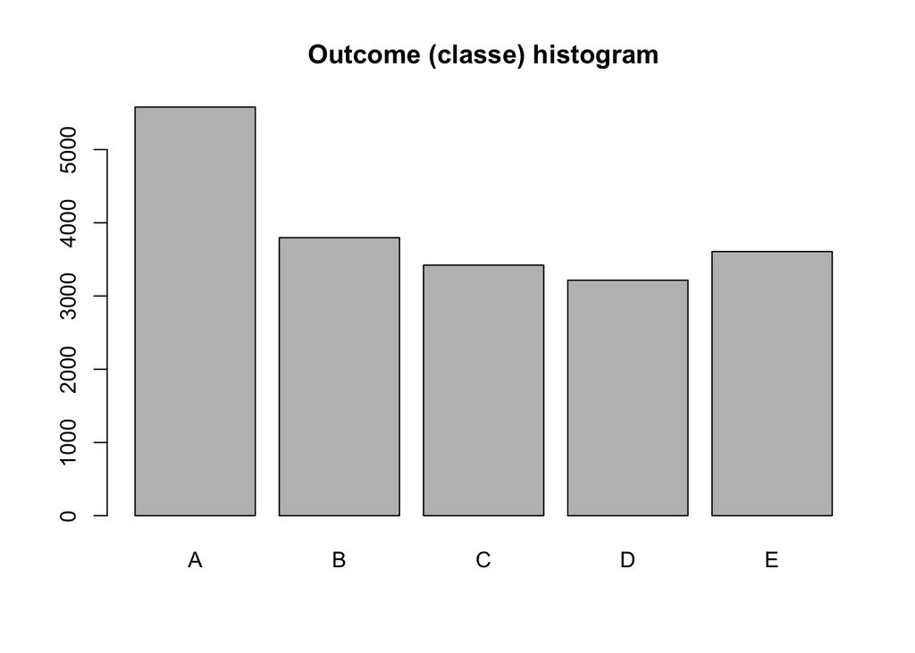

```r
par(mfrow=c(1,1))
plot(dat$classe, main="Outcome (classe) histogram")
```

We have a dataset of 19622 observations of 160 variables. But we also notice a large number of missing values, more or less completely contained within a limited set of variables.

On the other hand, the plot of classe shows that class A is the most numerous, with the other classes more or less equally represented.

To take care of the above described issues with our training dataset, we choose to omit the variables that include missing values. We also exclude the first 7 variables, since they only include data about the participants themselves and not necessarily about the movements they made.

```r
dat <- dat[, apply(dat, 2, function(x) !any(is.na(x)|x==""))]
dat <- dat[,-c(1:7)]

sum(is.na(dat))
```

```
## [1] 0
```

```r
str(dat)
```

```
## 'data.frame':    19622 obs. of  53 variables:
##  $ roll_belt           : num  1.41 1.41 1.42 1.48 1.48 1.45 1.42 1.42 1.43 1.45 ...
##  $ pitch_belt          : num  8.07 8.07 8.07 8.05 8.07 8.06 8.09 8.13 8.16 8.17 ...
##  $ yaw_belt            : num  -94.4 -94.4 -94.4 -94.4 -94.4 -94.4 -94.4 -94.4 -94.4 -94.4 ...
##  $ total_accel_belt    : int  3 3 3 3 3 3 3 3 3 3 ...
##  $ gyros_belt_x        : num  0 0.02 0 0.02 0.02 0.02 0.02 0.02 0.02 0.03 ...
##  $ gyros_belt_y        : num  0 0 0 0 0.02 0 0 0 0 0 ...
##  $ gyros_belt_z        : num  -0.02 -0.02 -0.02 -0.03 -0.02 -0.02 -0.02 -0.02 -0.02 0 ...
##  $ accel_belt_x        : int  -21 -22 -20 -22 -21 -21 -22 -22 -20 -21 ...
##  $ accel_belt_y        : int  4 4 5 3 2 4 3 4 2 4 ...
##  $ accel_belt_z        : int  22 22 23 21 24 21 21 21 24 22 ...
##  $ magnet_belt_x       : int  -3 -7 -2 -6 -6 0 -4 -2 1 -3 ...
##  $ magnet_belt_y       : int  599 608 600 604 600 603 599 603 602 609 ...
##  $ magnet_belt_z       : int  -313 -311 -305 -310 -302 -312 -311 -313 -312 -308 ...
##  $ roll_arm            : num  -128 -128 -128 -128 -128 -128 -128 -128 -128 -128 ...
```

[output cut: 39 more lines]

We see that these manipulations completely eliminate our missing values and leave us with a training set of 53 variables.

## Modelling

We are going to create two models: a Random Forest and a Gradient Boosting Machine. To be able to calculate an accurate Out-of-Sample accuracy (or inversely error) rate, we will split the training dataset in two segments, the first to fit the models and the second to evaluate them. Within each of the models, we also use cross-validation of three groups.

```r
inTrain <- createDataPartition(dat$classe, p=0.7, list=FALSE)

training <- dat[inTrain,]
testing <- dat[-inTrain,]

crossval <- trainControl(method="cv", number=3, allowParallel=T, verbose=F)

RFmdl <- train(classe~., data=training, method="rf", trControl=crossval)
GBMmdl <- train(classe~., data=training, method="gbm", trControl=crossval)

RFprd.in <- predict(RFmdl, training)
GBMprd.in <- predict(GBMmdl, training)

RFprd.out <- predict(RFmdl, testing)
GBMprd.out <- predict(GBMmdl, testing)
```

Before we evaluate the models, let us take a look at what variables they used to make the predictions.

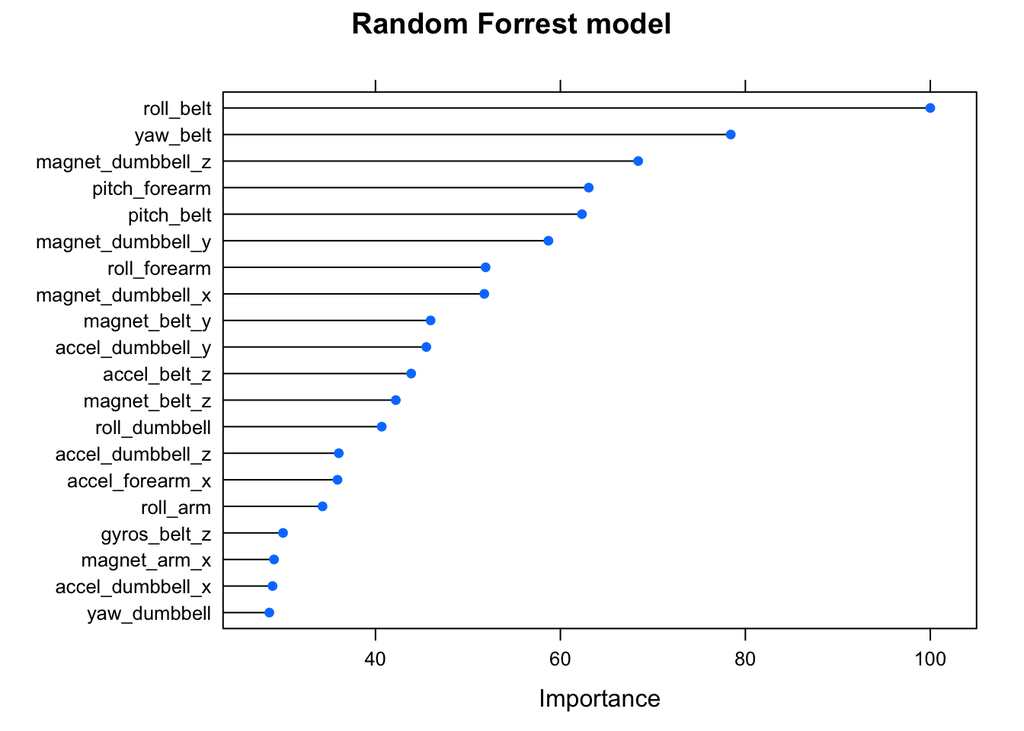

```r
plot(varImp(RFmdl), top = 20, main="Random Forrest model")
```

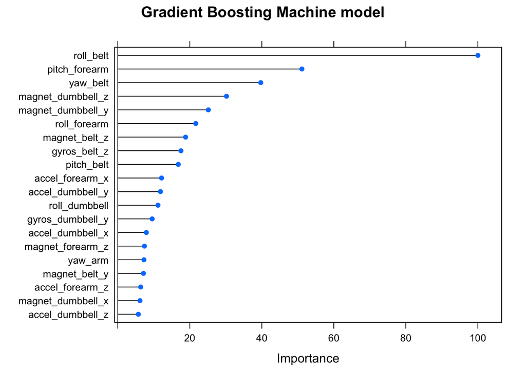

```r
plot(varImp(GBMmdl), top = 20, main="Gradient Boosting Machine model")
```

## In-Sample Evaluation

To get an idea of how our models perform, we can use confusion matrices to calculate In-Sample accuracy and other rates, as seen below.

```r
confusionMatrix(RFprd.in, training$classe)
```

```
## Confusion Matrix and Statistics
##
##           Reference
## Prediction    A    B    C    D    E
##          A 3906    0    0    0    0
##          B    0 2658    0    0    0
##          C    0    0 2396    0    0
##          D    0    0    0 2252    0
##          E    0    0    0    0 2525
##
## Overall Statistics
##
##                Accuracy : 1
##                  95% CI : (0.9997, 1)
##     No Information Rate : 0.2843
##     P-Value [Acc > NIR] : < 2.2e-16
##
##                   Kappa : 1
##  Mcnemar's Test P-Value : NA
##
## Statistics by Class:
##
##                      Class: A Class: B Class: C Class: D Class: E
## Sensitivity            1.0000   1.0000   1.0000   1.0000   1.0000
## Specificity            1.0000   1.0000   1.0000   1.0000   1.0000
## Pos Pred Value         1.0000   1.0000   1.0000   1.0000   1.0000
## Neg Pred Value         1.0000   1.0000   1.0000   1.0000   1.0000
## Prevalence             0.2843   0.1935   0.1744   0.1639   0.1838
## Detection Rate         0.2843   0.1935   0.1744   0.1639   0.1838
## Detection Prevalence   0.2843   0.1935   0.1744   0.1639   0.1838
## Balanced Accuracy      1.0000   1.0000   1.0000   1.0000   1.0000
```

```r
confusionMatrix(GBMprd.in, training$classe)
```

```
## Confusion Matrix and Statistics
##
##           Reference
## Prediction    A    B    C    D    E
##          A 3870   67    0    2    1
##          B   23 2550   46    4   14
##          C    6   41 2324   53   15
##          D    6    0   23 2181   22
##          E    1    0    3   12 2473
##
## Overall Statistics
##
##                Accuracy : 0.9753
##                  95% CI : (0.9726, 0.9779)
##     No Information Rate : 0.2843
##     P-Value [Acc > NIR] : < 2.2e-16
##
##                   Kappa : 0.9688
##  Mcnemar's Test P-Value : 3.423e-11
##
## Statistics by Class:
##
##                      Class: A Class: B Class: C Class: D Class: E
## Sensitivity            0.9908   0.9594   0.9699   0.9685   0.9794
## Specificity            0.9929   0.9921   0.9899   0.9956   0.9986
## Pos Pred Value         0.9822   0.9670   0.9528   0.9772   0.9936
## Neg Pred Value         0.9963   0.9903   0.9936   0.9938   0.9954
## Prevalence             0.2843   0.1935   0.1744   0.1639   0.1838
## Detection Rate         0.2817   0.1856   0.1692   0.1588   0.1800
## Detection Prevalence   0.2868   0.1920   0.1775   0.1625   0.1812
## Balanced Accuracy      0.9918   0.9758   0.9799   0.9820   0.9890
```

## Out-of-Sample Evaluation

To more realistically evaluate the accuracy of models we created, we again calculate confusion matrices, but this time we attempt to predict from and compare with the testing dataset, which was not used to fit the models. Therefore, this can be considered as Out-of-Sample evaluation.

```r
confusionMatrix(RFprd.out, testing$classe)
```

```
## Confusion Matrix and Statistics
##
##           Reference
## Prediction    A    B    C    D    E
##          A 1674    8    0    0    0
##          B    0 1130    6    0    0
##          C    0    1 1020   13    0
##          D    0    0    0  949    2
##          E    0    0    0    2 1080
##
## Overall Statistics
##
##                Accuracy : 0.9946
##                  95% CI : (0.9923, 0.9963)
##     No Information Rate : 0.2845
##     P-Value [Acc > NIR] : < 2.2e-16
##
##                   Kappa : 0.9931
##  Mcnemar's Test P-Value : NA
##
## Statistics by Class:
##
##                      Class: A Class: B Class: C Class: D Class: E
## Sensitivity            1.0000   0.9921   0.9942   0.9844   0.9982
## Specificity            0.9981   0.9987   0.9971   0.9996   0.9996
## Pos Pred Value         0.9952   0.9947   0.9865   0.9979   0.9982
## Neg Pred Value         1.0000   0.9981   0.9988   0.9970   0.9996
## Prevalence             0.2845   0.1935   0.1743   0.1638   0.1839
## Detection Rate         0.2845   0.1920   0.1733   0.1613   0.1835
## Detection Prevalence   0.2858   0.1930   0.1757   0.1616   0.1839
## Balanced Accuracy      0.9991   0.9954   0.9956   0.9920   0.9989
```

```r
confusionMatrix(GBMprd.out, testing$classe)
```

```
## Confusion Matrix and Statistics
##
##           Reference
## Prediction    A    B    C    D    E
##          A 1648   38    0    1    2
##          B   19 1072   33    1   13
##          C    3   29  983   25   13
##          D    3    0    9  927   11
##          E    1    0    1   10 1043
##
## Overall Statistics
##
##                Accuracy : 0.964
##                  95% CI : (0.9589, 0.9686)
##     No Information Rate : 0.2845
##     P-Value [Acc > NIR] : < 2.2e-16
##
##                   Kappa : 0.9544
##  Mcnemar's Test P-Value : 5.427e-06
##
## Statistics by Class:
##
##                      Class: A Class: B Class: C Class: D Class: E
## Sensitivity            0.9845   0.9412   0.9581   0.9616   0.9640
## Specificity            0.9903   0.9861   0.9856   0.9953   0.9975
## Pos Pred Value         0.9757   0.9420   0.9335   0.9758   0.9886
## Neg Pred Value         0.9938   0.9859   0.9911   0.9925   0.9919
## Prevalence             0.2845   0.1935   0.1743   0.1638   0.1839
## Detection Rate         0.2800   0.1822   0.1670   0.1575   0.1772
## Detection Prevalence   0.2870   0.1934   0.1789   0.1614   0.1793
## Balanced Accuracy      0.9874   0.9636   0.9718   0.9785   0.9807
```

We see that the Random Forest model performs better and yields an Out-of-Sample accuracy of 0.9946.

## Prediction (and Validation)

The last step is using our models to predict for the validation set. The output below shows almost perfect agreement between the created models, mirroring the accuracy values above.

```r
RFval <- predict(RFmdl, validation)
GBMval <- predict(GBMmdl, validation)

data.frame(RFval, GBMval)
```

```
##    RFval GBMval
## 1      B      B
## 2      A      A
## 3      B      B
## 4      A      A
## 5      A      A
## 6      E      E
## 7      D      D
## 8      B      B
## 9      A      A
## 10     A      A
## 11     B      B
## 12     C      C
## 13     B      B
## 14     A      A
## 15     E      E
## 16     E      E
## 17     A      A
## 18     B      B
## 19     B      B
## 20     B      B
```